# European differences in educational attainment

Jonas Schöley

2018-05-23

Here I demonstrate how to use the `tricolore` library to color-code a choropleth map of Europe according to the regional distribution of educational attainment.

```r
library(tricolore)
euro_education
```

```
#> # A tibble: 324 x 4
#>    id    ed0_2 ed3_4 ed5_8
#>    <chr> <dbl> <dbl> <dbl>
#>  1 AT11  0.165 0.557 0.279
#>  2 AT12  0.147 0.551 0.302
#>  3 AT13  0.169 0.432 0.399
#>  4 AT21  0.106 0.6   0.294
#>  5 AT22  0.14  0.586 0.274
#>  6 AT31  0.157 0.553 0.291
#>  7 AT32  0.138 0.547 0.315
#>  8 AT33  0.179 0.539 0.282
#>  9 AT34  0.196 0.527 0.277
#> 10 BE10  0.291 0.269 0.441
#> # ... with 314 more rows
```

The data set `euro_education` contains the relative share of population by educational attainment in the European regions 2016. The variable `id` gives the [NUTS-2](https://en.wikipedia.org/wiki/Nomenclature_of_Territorial_Units_for_Statistics) geocodes for the European regions, the variables `ed0_2`, `ed3_4`, `ed5_8` give the proportion of population by highest educational attainment classified via the [ISCED](https://en.wikipedia.org/wiki/International_Standard_Classification_of_Education) system.

Take the first row of the data set as an example: in the Austrian region of “Burgenland” (`id` = `AT11`) 16.5% of the population aged 25–64 had attained an education of “Lower secondary or less” (`ed0_2`), 55.7% attained “upper secondary” education (`ed3_4`), and 27.9% attained “tertiary” education.

The education composition is *ternary*, i.e. made up from three elements, and therefore can be color-coded as the weighted mixture of three primary colors, each primary mapped to one of the three elements. Such a color scale is called a *ternary balance scheme*[^1]. This is what `tricolore` does.

It takes three steps to transform the compositional data and the geodata of Europe into a ternary color-coded map:

**1. Using the `Tricolore()` function, color-code each composition in the `euro_education` data set and add the resulting vector of hex-srgb colors as a new variable to the data frame. Store the color key seperately.**

```r
# color-code the data set and generate a color-key
tric <- Tricolore(euro_education, p1 = 'ed0_2', p2 = 'ed3_4', p3 = 'ed5_8',
                  breaks = 4)
```

`tric` contains both a vector of color-coded compositions (`tric$hexsrgb`) and the corresponding color key (`tric$legend`).

```r
# add the vector of colors to the `euro_education` data
euro_education$rgb <- tric$hexsrgb
euro_education
```

```
#> # A tibble: 324 x 5
#>    id    ed0_2 ed3_4 ed5_8 rgb
#>    <chr> <dbl> <dbl> <dbl> <chr>
#>  1 AT11  0.165 0.557 0.279 #049465FF
#>  2 AT12  0.147 0.551 0.302 #049465FF
#>  3 AT13  0.169 0.432 0.399 #3F7F78FF
#>  4 AT21  0.106 0.6   0.294 #049465FF
#>  5 AT22  0.14  0.586 0.274 #049465FF
#>  6 AT31  0.157 0.553 0.291 #049465FF
#>  7 AT32  0.138 0.547 0.315 #049465FF
#>  8 AT33  0.179 0.539 0.282 #049465FF
#>  9 AT34  0.196 0.527 0.277 #049465FF
#> 10 BE10  0.291 0.269 0.441 #636363FF
#> # ... with 314 more rows
```

**2. Join the color-coded `euro_education` data frame with a data frame holding the geodata of the European NUTS-2 regions.**

`tricolore` comes with low resolution geodata of the European NUTS-2 regions (`euro_geo_nuts2`) which I’m gonna use for this map.

```r
# merge the geodata with the color-coded compositional data
euro_educ_map <- dplyr::left_join(euro_education, euro_geo_nuts2, by = 'id')
```

**3. Using `ggplot2` and the joined color-coded education data and geodata, plot a ternary choropleth map of education attainment in the European regions. Add the color key to the map.**

The secret ingredient is `scale_fill_identity()` to make sure that each region is colored according to the value in the `rgb` variable of `euro_educ_map`.

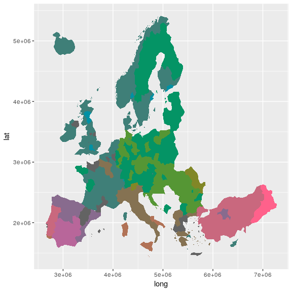

```r
library(ggplot2)

plot_educ <-
  # using data `euro_educ_map`...
  ggplot(euro_educ_map) +
  # ...draw a polygon for each `group` along `long` and `lat`...
  geom_polygon(aes(x = long, y = lat, group = group, fill = rgb)) +
  # ...and color each region according to the color code in the variable `rgb`
  scale_fill_identity()

plot_educ
```

Using `annotation_custom()` and `ggplotGrob` we can add the color key produced by `Tricolore()` to the map. Internally, the color key is produced with the [`ggtern`](http://www.ggtern.com/) package. In order for it to render correctly we need to load `ggtern` *after* loading `ggplot2`. Don’t worry, the `ggplot2` functions still work.

```r
library(ggtern)
```

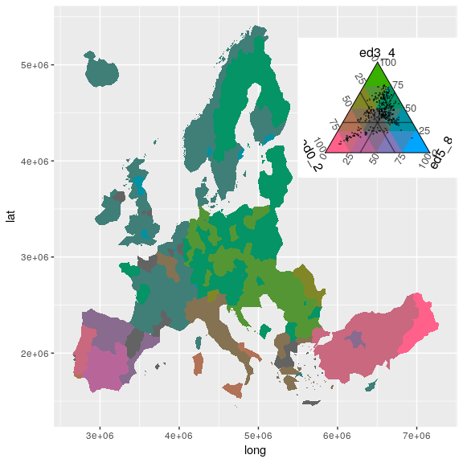

```r
plot_educ +
  annotation_custom(
    ggplotGrob(tric$legend),
    xmin = 55e5, xmax = Inf, ymin = 35e5, ymax = Inf
  )
```

Because the color key behaves just like a `ggplot2` plot we can change it to our liking.

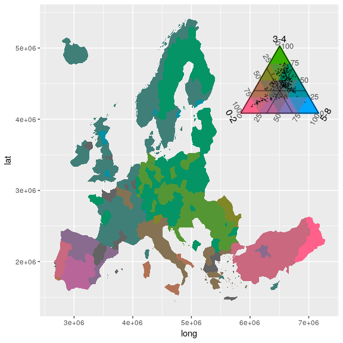

```r
plot_educ <-
  plot_educ +
  annotation_custom(
    ggplotGrob(tric$legend +
                 theme(plot.background = element_rect(fill = NA, color = NA)) +
                 labs(L = '0-2', T = '3-4', R = '5-8')),
    xmin = 55e5, xmax = Inf, ymin = 35e5, ymax = Inf
  )
plot_educ
```

Some final touches…[^2]

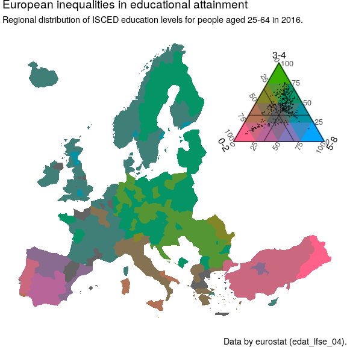

```r
plot_educ +
  theme_void() +
  labs(title = 'European inequalities in educational attainment',
       subtitle = 'Regional distribution of ISCED education levels for people aged 25-64 in 2016.',
       caption = 'Data by eurostat (edat_lfse_04).')
```

## Literature

Brewer, C. A. (1994). Color Use Guidelines for Mapping and Visualization. In A. M. MacEachren & D. R. F. Taylor (Eds.), Visualization in Modern Cartography (pp. 123–147). Oxford, UK: Pergamon.

Dorling, D. (2012). The Visualization of Spatial Social Structure. Chichester, UK: Wiley. Retrieved from https://sasi.group.shef.ac.uk/thesis/prints.html

[^1]: See for example Dorling (2012) and Brewer (1994).
[^2]: In these maps some cities are colored wrong. The problem and a solution are described [here](https://stackoverflow.com/questions/21748852/choropleth-map-in-ggplot-with-polygons-that-have-holes/32186989#32186989). I’ve omitted the fix here for reasons of brevity.